# Two-Sample Means (Dependent) - Week 2, Lecture 2

Author

Hector Gavilanes

```r
#install.packages("formattable")
library(tidyverse)
library(gsheet)
library(formattable)
library(gridExtra)
```

**A new 2 hour reading comprehension program has been developed by a local tutoring center. A pilot study of 30 students has been conducted and we have data on a reading comprehension test taken before the program and a separate reading comprehension test taken after the program. Consider the data, found in the following Google Sheet.**

```r
data <- as_tibble(gsheet2tbl("https://docs.google.com/spreadsheets/d/1ijxX7c6qcFAw-r_mNSxC-Ps5b5njw-WtE4RcxPTySXU/edit?usp=sharing"))

# ---FUNCTIONS---
# Change default table format
change_table_format <- function(data_table){
  formattable(data_table, align =c("l",rep("c", NCOL(data_table) - 1)))
}
```

#### 1. Summarize the data. Provide appropriate summary statistics for the pilot study.

```r
# summary with standard deviation by department
summary_table <- data %>%
  drop_na() %>%
  select(Pre, Post) %>%
  summarise_all(list(Avg = mean,
                      SD = sd,
                      Median = median,
                      Variance = var,
                      Min = min,
                      Max = max))

change_table_format(summary_table)
```

| Pre_Avg | Post_Avg | Pre_SD | Post_SD | Pre_Median | Post_Median | Pre_Variance | Post_Variance | Pre_Min | Post_Min | Pre_Max | Post_Max |
| --- | --- | --- | --- | --- | --- | --- | --- | --- | --- | --- | --- |
| 71.43333 | 75.23333 | 11.42497 | 13.28905 | 72.5 | 75 | 130.5299 | 176.5989 | 48 | 49 | 94 | 98 |

#### 2. Construct the 95% confidence interval for the difference in test scores. Hint: we want to discuss this in terms of the *increase* in test scores.

```r
t.test(data$Pre, data$Post,
       paired = TRUE)
```

```
    Paired t-test

data:  data$Pre and data$Post
t = -4.9496, df = 29, p-value = 2.918e-05
alternative hypothesis: true mean difference is not equal to 0
95 percent confidence interval:
 -5.370205 -2.229795
sample estimates:
mean difference
           -3.8
```

The 95% CI is (-5.37, -2.23)

#### 3. Use the appropriate hypothesis test to determine if the program raises comprehension test averages by at least 5 points. Test at the α=0.05 level.

```r
t.test(data$Pre, data$Post,
       paired = TRUE,
       alternative = "greater")
```

```
    Paired t-test

data:  data$Pre and data$Post
t = -4.9496, df = 29, p-value = 1
alternative hypothesis: true mean difference is greater than 0
95 percent confidence interval:
 -5.104488       Inf
sample estimates:
mean difference
           -3.8
```

### Hypothesis

H0: $\mu_Pre \le \mu_Post$  
H1: $\mu_Pre > \mu_Post$

### p-Value

p = 1

#### 4. (Challenge!) Construct a graph that will help you explain your findings to the tutoring center.

### Assumptions - Reading Pilot Program

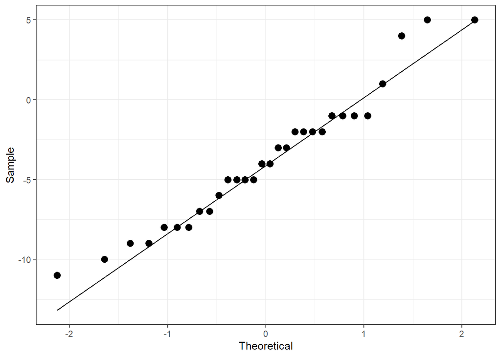

```r
qq_graph <- data %>%
  mutate(diff = Pre - Post) %>%
  ggplot(aes(sample = diff))+
  stat_qq(size = 3)+
  stat_qq_line()+
  theme_bw()+
  xlab("Theoretical")+
  ylab("Sample")
qq_graph
```

### Boxplots - Reading Pilot Program

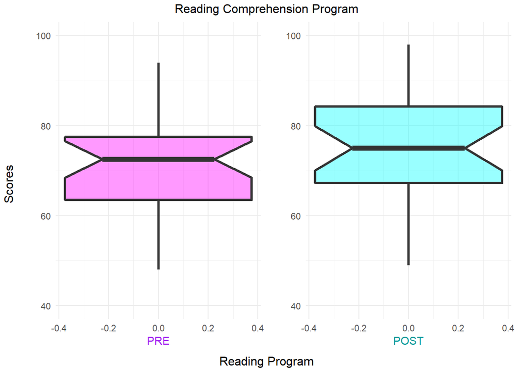

```r
# Graph Boxplot
plot_boxes <- function(y_cord, fill_color, x_label, txt_color){
  data %>%
    ggplot(aes(y=y_cord))+
    geom_boxplot(fill=fill_color, alpha=0.4, size=1.2, notch = TRUE, notchwidth = 0.6)+
    xlab(x_label)+
    ylab("")+
    ylim(40,100)+
    theme_minimal()+
    theme(text=element_text(color=txt_color))
}

pre_plot <- plot_boxes(data$Pre, "magenta", "PRE", "purple")
post_plot <- plot_boxes(data$Post, "cyan", "POST", "#009999")
grid.arrange(pre_plot, post_plot, nrow=1, bottom = "Reading Program", left = "Scores", top = "Reading Comprehension Program")
```

#### 5. Write a brief paragraph explaining your findings to the tutoring center.

The tutoring center should continue developing similar programs for other classes because students are improving their grade scores.